# Atteggiamento dei cittadini italiani nei confronti della sicurezza informatica

Luglio 2021

## Questionario - Eurobarometer 92.2

Tra l’8 e il 22 Ottobre 2019 la Commissione Europea ha sottoposto a 27,607 cittadini dei 28 stati membri dell’ Unione un [questionario](https://europa.eu/eurobarometer/surveys/detail/2249) per comprendere la consapevolezza, l’esperienza e la percezione nei confronti della sicurezza informatica: i cittadini italiani intervistati sono stati 1023, di età compresa tra 15 e 90 anni.

Le domande riguardavano vari aspetti della vita *digitale* dei cittadini: dai dispositivi usati per accedere ad Internet, alle preoccupazioni sull’utilizzo dell’home banking o l’acquisto online, dai crimini di cui sono stati vittime, alla conoscenza di metodi per segnalare abusi.

I risultati della ricerca sono stati pubblicati a gennaio 2020: diamo uno sguardo più approfondito all’atteggiamento degli italiani.

## Intervistati

## Età

L’età media dei partecipanti è 51 anni, con una leggera maggioranza di donne (51%).

La differenza di genere è minima fino ai 44 anni, poi nella fascia 45-64 abbiamo la maggioranza di partecipanti donne ed infine un maggioranza di uomini nella fascia 65 e oltre.

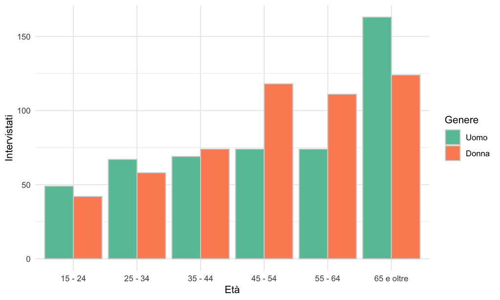

## Dove vivono

Oltre il 65% degli intervistati vive in piccole o medie città.

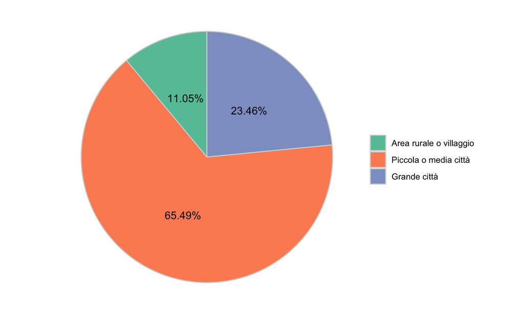

Lombardia, Campania, Lazio e Sicilia sono le regioni con il più alto numero di intervistati.

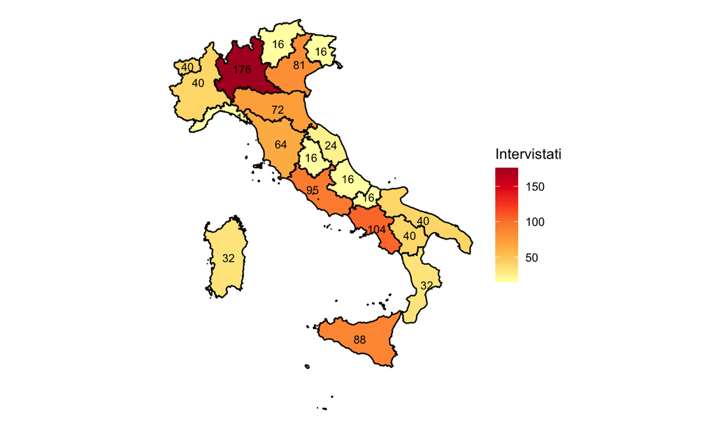

## Grado di istruzione

Il 40% degli intervistati ha completato la scuola secondaria di secondo grado.

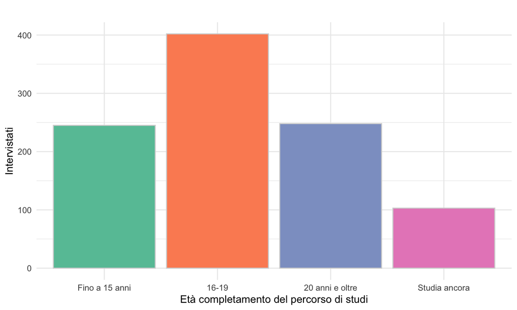

## Uso di Internet

## Frequenza collegamento Internet

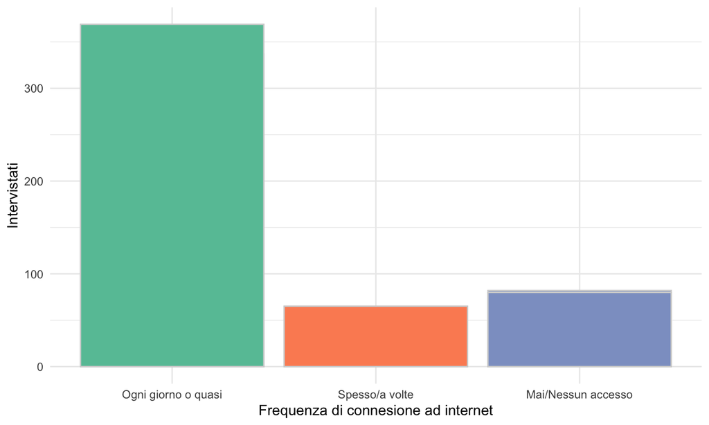

Tutti gli intervistati utilizzano Internet prevalentemente ogni giorno, tranne quelli di 65 anni e oltre, dove la maggior parte non si collega mai, oppure non ha possibilità di collegarsi.

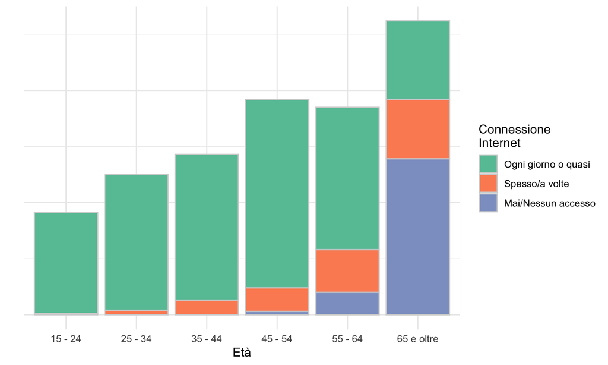

Gli intervistati con grado di istruzione inferiore tendono a collegarsi meno: solo il 29% si collega ogni giorno, rispetto al 99% di chi studia ancora.

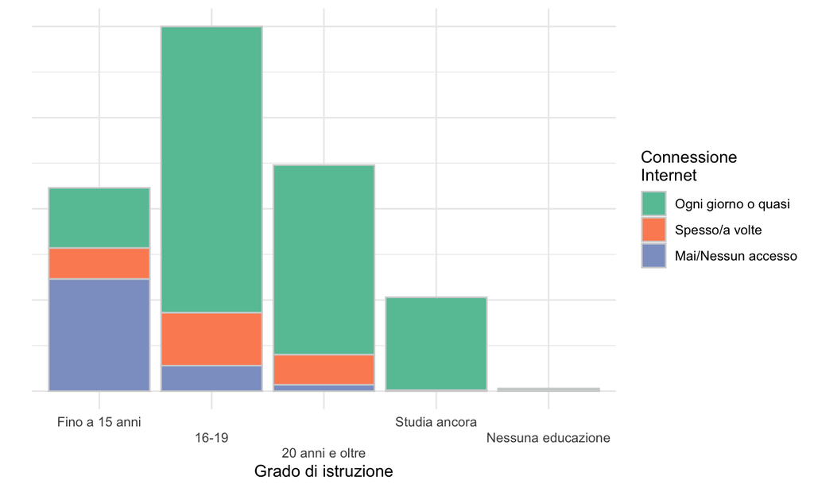

## Strumento utilizzato

Lo smartphone è lo strumento più usato per connettersi ad internet (40%), seguito dal personal computer (27%).

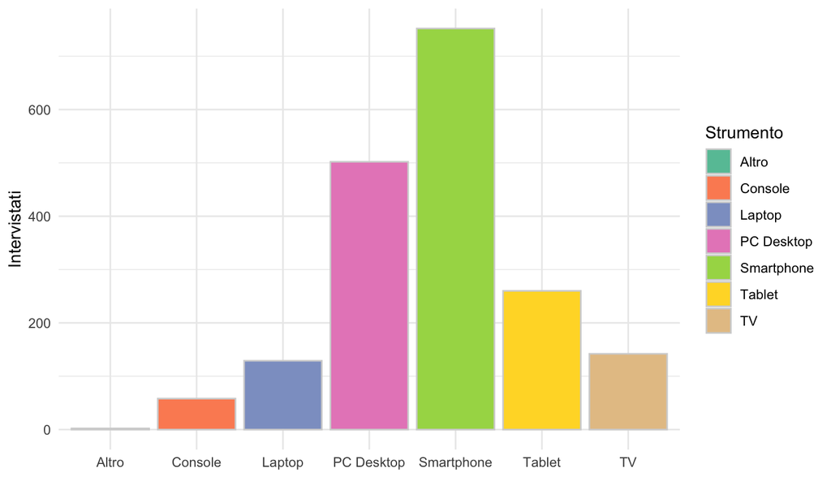

## Attività online

Lo scambio di email (14%), la messaggistica (13%), i social network (12%) e lo scambio di informazioni su forum/blog (11%) sono le principali attività degli intervistati.

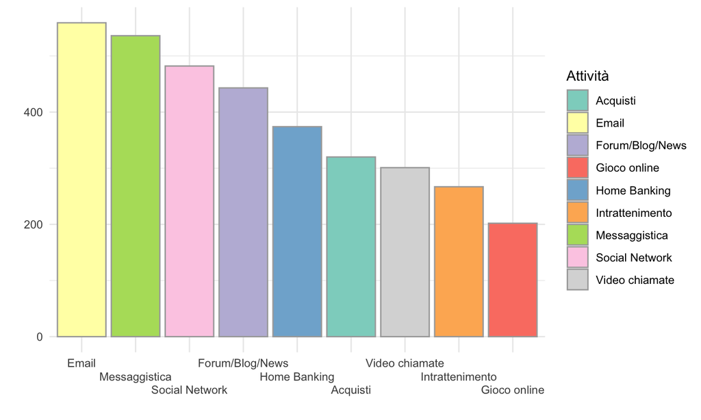

L’uso dei social network viene sostituito dalle operazioni di home banking per gli intervistati con età superiore di 55 anni.

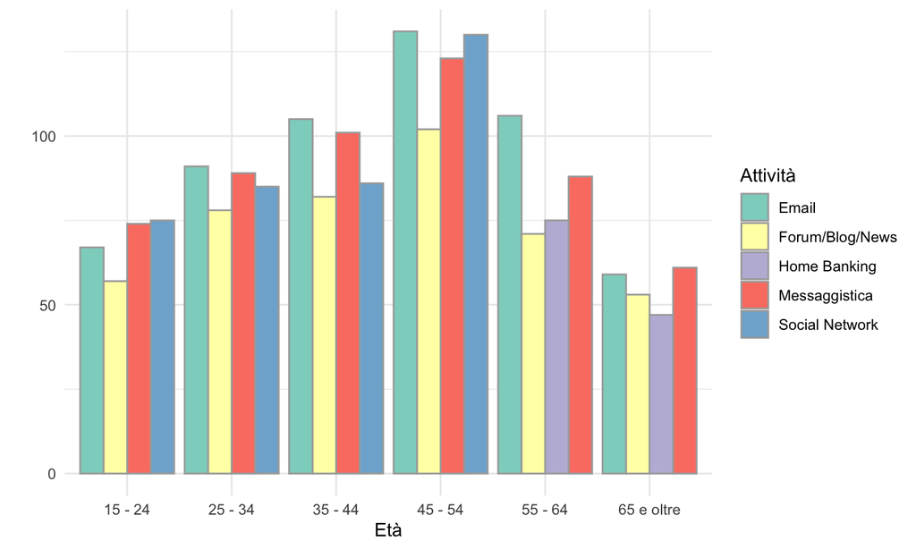

## Proccupazioni nell’uso di Internet

## Pagamenti online

La sicurezza dei pagamenti (27%) e l’uso improprio dei dati personali (27%) sono le principali preoccupazioni degli intervistati quando effettuano pagamenti online per l’acquisto di beni o servizi.

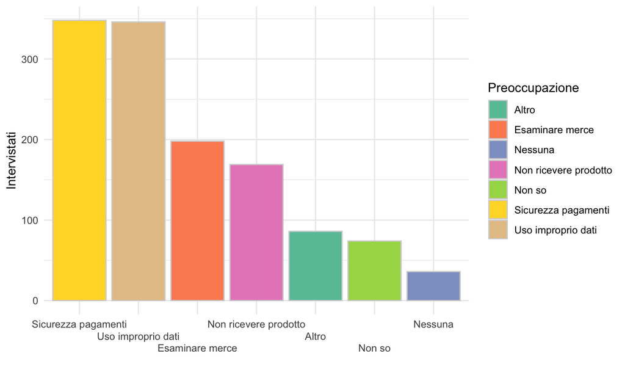

## Cambio password

La maggior parte degli intervistati (65%) ha cambiato almeno una password dei propri servizi online negli ultimi 12 mesi. La password del proprio account email è quella maggiormente cambiata (22%), seguita da quella dell’home banking (14%) e dei Social (11%). Solo il 6% ha cambiato la password su un sito di acquisti online, percentuale che scende al 3% per la password dei siti dei servizi pubblici e delle piattaforme di gioco online. Circa un intervistato su dieci ha cambiato la password per altri servizi online.

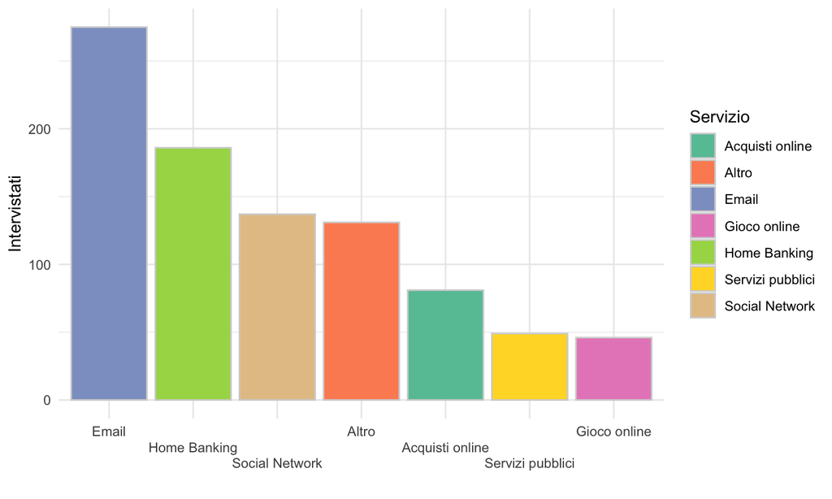

La password dell’account email resta quella più cambiata dagli intervistati fino a 44 anni. Dai 45 anni in poi prevale la totale assenza di cambio password negli ultimi 12 mesi.

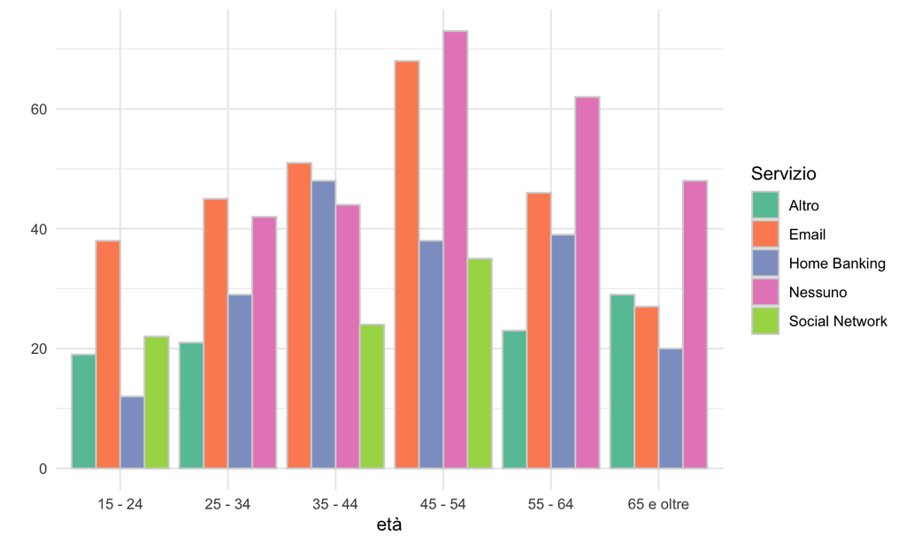

Anche il grado di istruzione influenza la scelta di cambiare o meno la password per i propri servizi online.

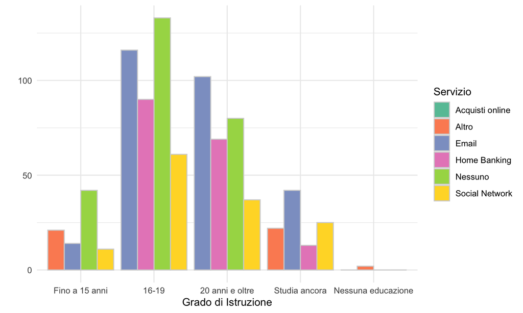

## Comportamento online

Le preoccupazioni riguardo la privacy e la sicurezza online, hanno fatto cambiare il comportamento del 97% degli intervistati. Il 12% non apre mail provenienti da sconosciuti, ha installato un software antivirus (11%) o visita solo siti che conosce (11%).

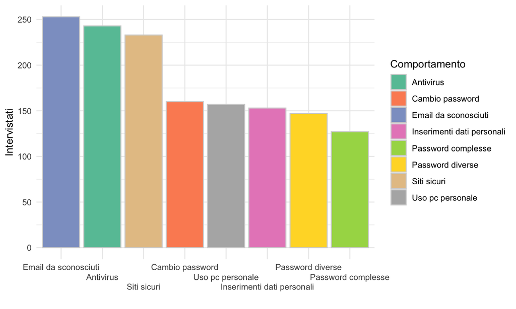

## Conoscenza e preoccupazioni

## Livello di conoscenza

Il 40% degli intervistati reputa di non essere abbastanza informato sui rischi dei crimini informatici, addirittura il 28% reputa di essere molto poco informato mentre solo poco più dell’1% ritiene di essere bene informato.

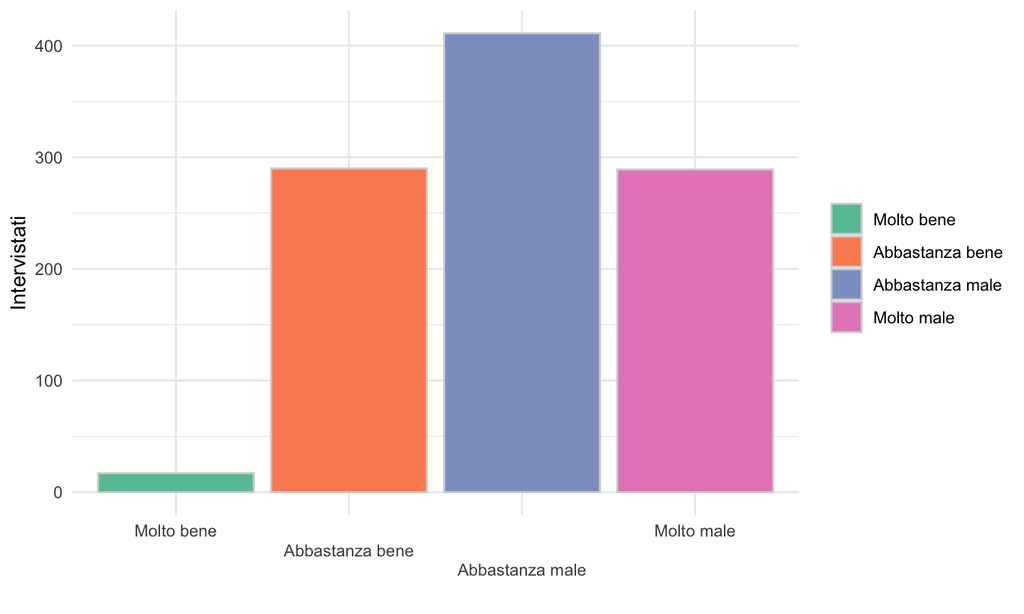

I più giovani (15-34) ritengono di essere bene informati, mentre gli intervistati di oltre 65 anni reputano di essere molto poco informati.

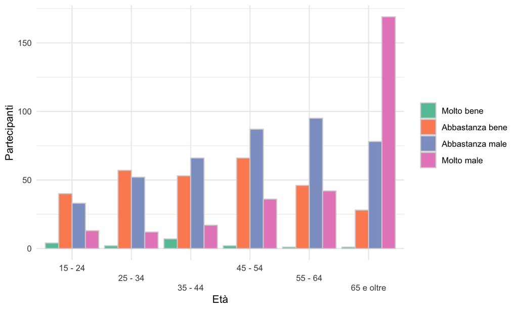

Gli intervistati con un basso grado di istruzione di sentono molto poco informati sui crimini informatici, mentre solo chi sta ancora studiando ritiene di essere bene informato.

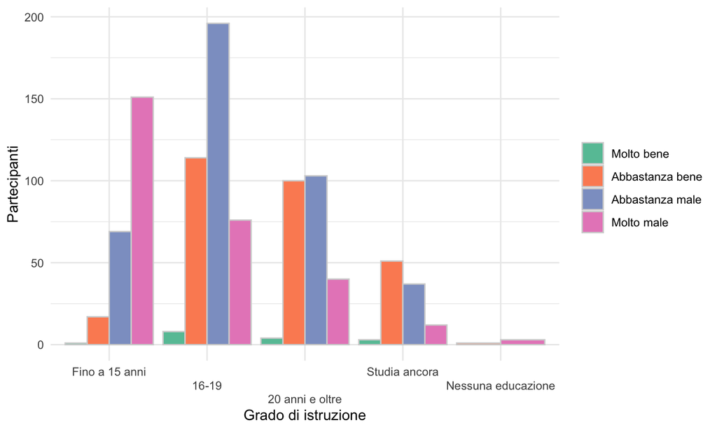

## Conoscenza canali ufficiali

Solo il 22% degli intervistati è a conoscenza dei canali ufficiali per segnalare un crimine informatico o qualsiasi altro comportamento illegale online. Un numero di telefono (26%) è il modo più conosciuto, seguito da altro metodi (23%) mentre solo un intervistato su cinque conosce il [sito web ufficiale](https://denunceviaweb.poliziadistato.it/polposta).

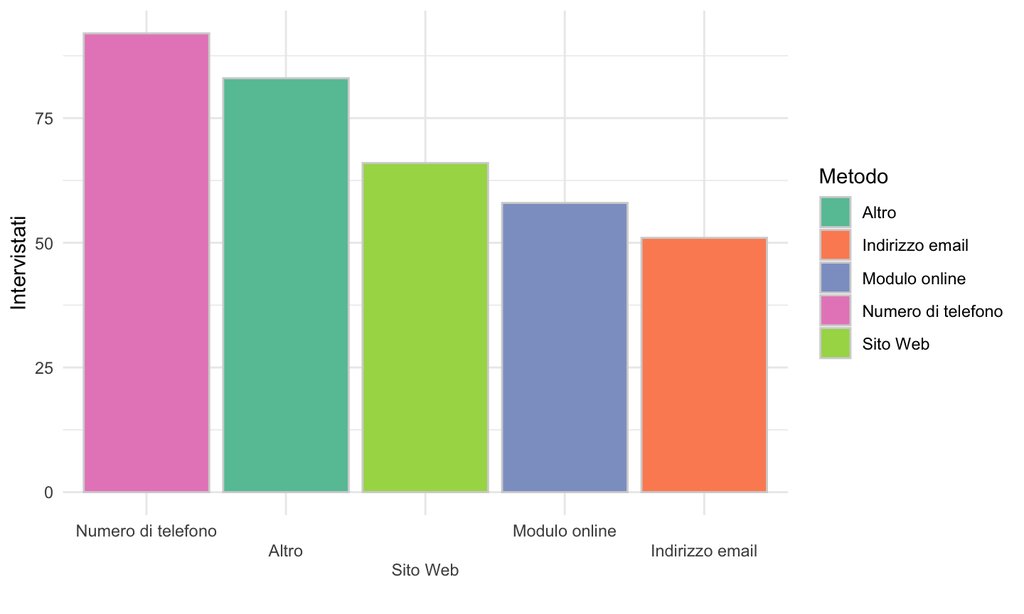

## Azioni per tutelarsi

Anche se un intervistato su tre evita di comunicare informazioni personali online (31%), ben uno su cinque ha paura di diventare vittima di un crimine informatico (22%). Inoltre, solo un intervistato su dieci ritiene di essere in grado di tutelarsi adeguatamente contro i crimini informatici (9%).

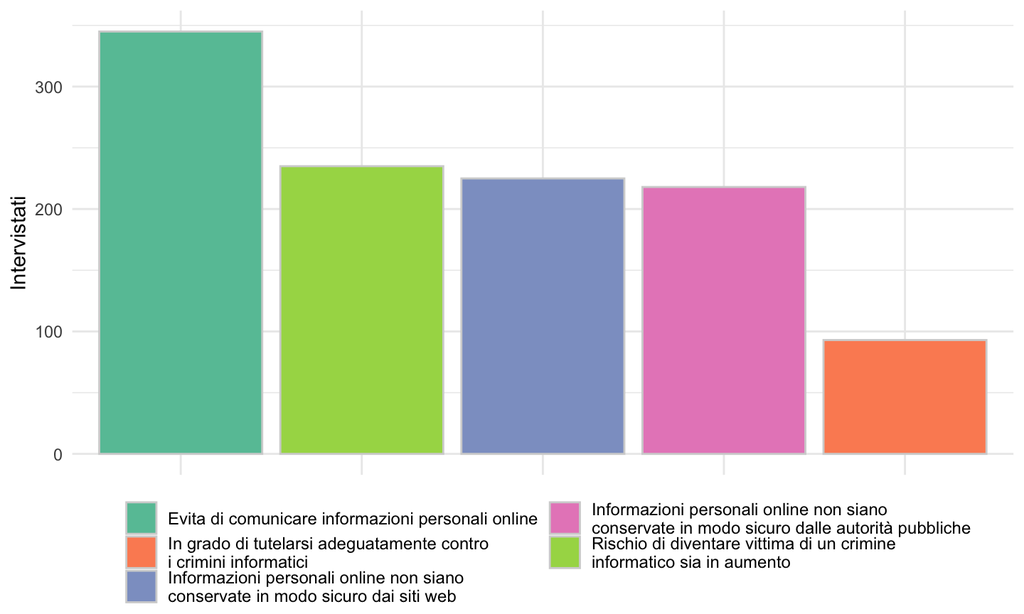

## Preoccupazioni

La maggioranza degli intervistati sono preoccupati di essere vittime di un crimine informatico. Oltre due terzi è preoccupato dalla possibilità che il proprio dispositivo venga infettato da software dannosi (73%), che qualcuno rubi i dati personali e agisca al loro posto (70%), di essere vittime di frodi online legate alla carta di credito o a transazioni bancarie online (69%), di non riuscire ad accedere ai servizi online come i servizi bancari e i servizi pubblici (69%) oppure di subire un attacco hacker all’account e‐mail o all’account su social network (68%).

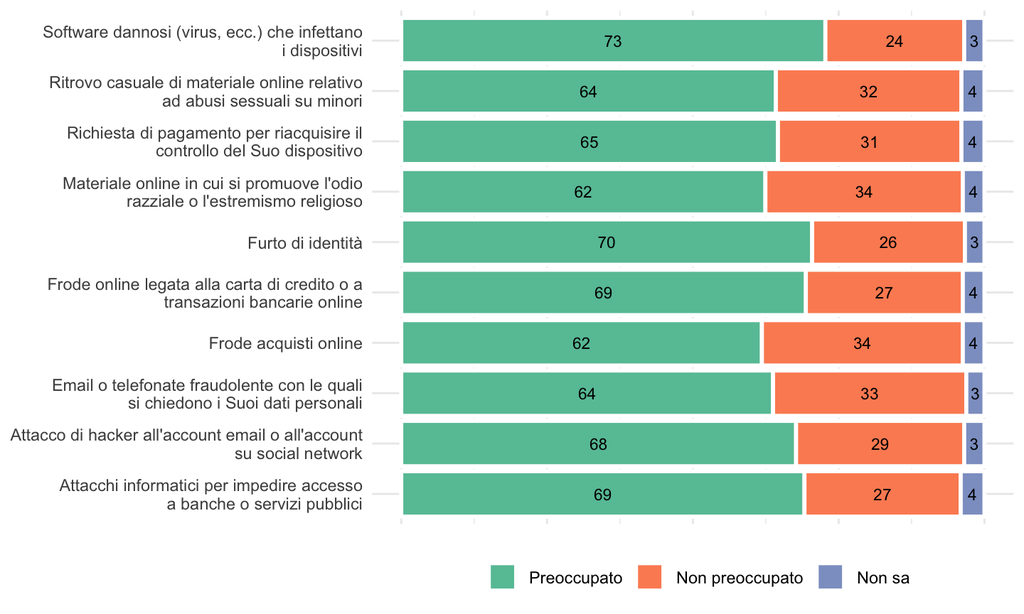

## Esperienza dei crimini informatici

## Esperienze personali di crimini informatici

Negli ultimi tre anni solo una minima parte degli intervistati è stata vittima di un crimine informatico: la ricezione di e‐mail o telefonate fraudolente con le quali si chiedono i dati personali (26%) è stato il più diffuso. A seguire la scoperta di software dannosi (virus, ecc.) sul proprio dispositivo (22%), ma sono gli unici *crimini* segnalati da almeno un intervistato su cinque.

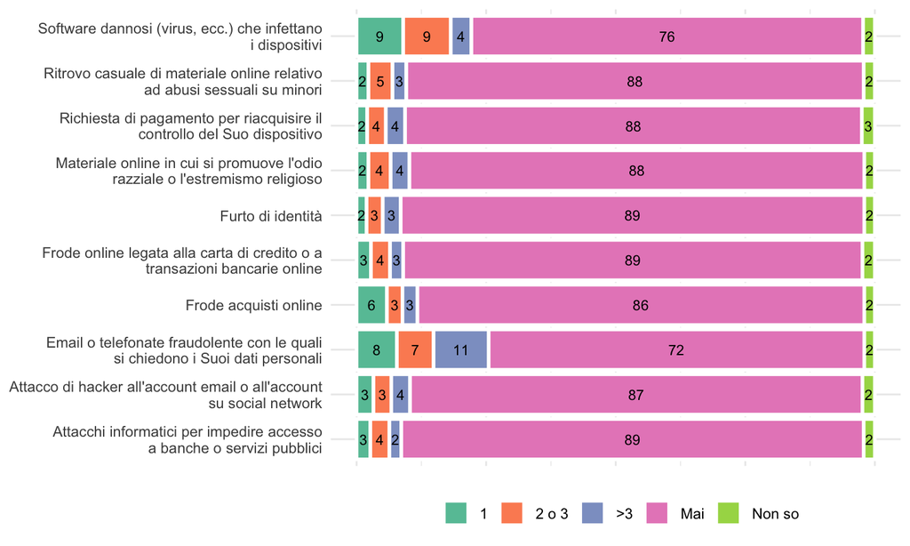

Gli uomini, in generale, sono stati vittime più delle donne: ad esempio il 12% ha scoperto software dannosi (virus, ecc.) installati nei propri dispositivi, rispetto al 9% delle donne.

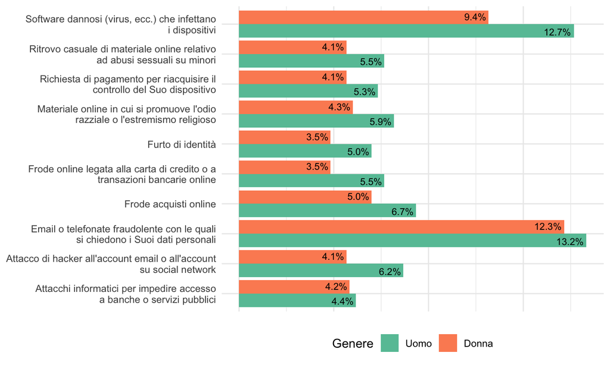

Il tipo di *crimine* cambia per gli intervistati di 65 anni e oltre: sono più soggetti a frodi per acquisti online o al ritrovamento di materiale relativo ad abusi sessuali su minori.

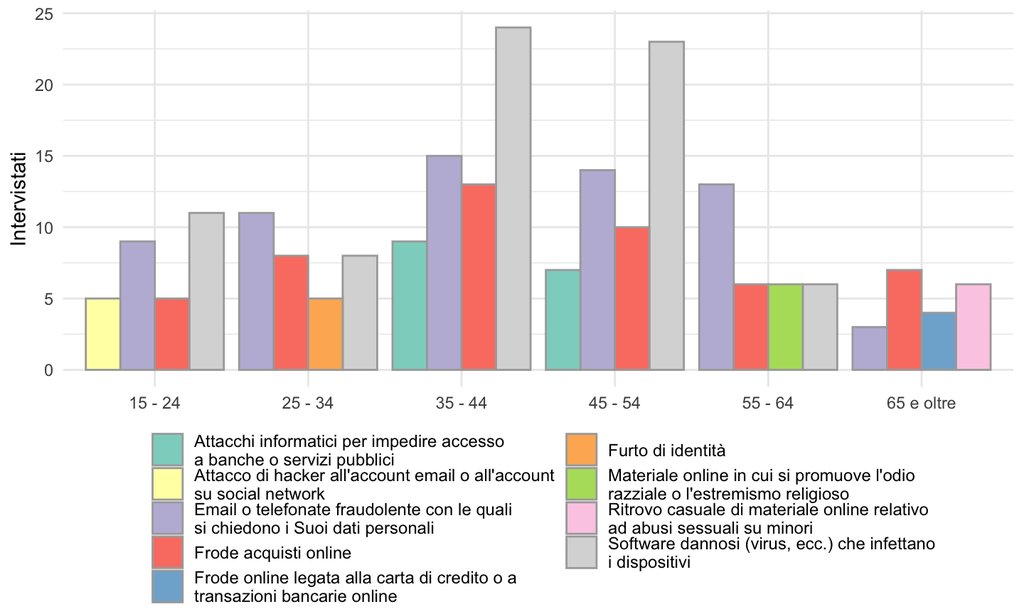

## Azioni intraprese dalle vittime

Gli intervistati che hanno subito una frode online legata alla carta di credito o a transazioni bancarie sono quelli che hanno segnalato maggiormente il problema (88%), seguiti da chi è stato vittima del furto di identità (85%), da chi ha subito un attacchi informatici che ha impedito l’accesso ai servizi bancari e i servizi pubblici online (85%) e a chi ha ritrovato casualmente materiale relativo ad abusi sessuali su minori (84%).

Mentre solo due intervistati su tre hanno segnalato la scoperta di software dannosi (virus, ecc.) sul proprio dispositivo (64%) e solo uno ogni due la ricezione di e‐mail o telefonate fraudolente con le quali si chiedevano i dati personali (51%).

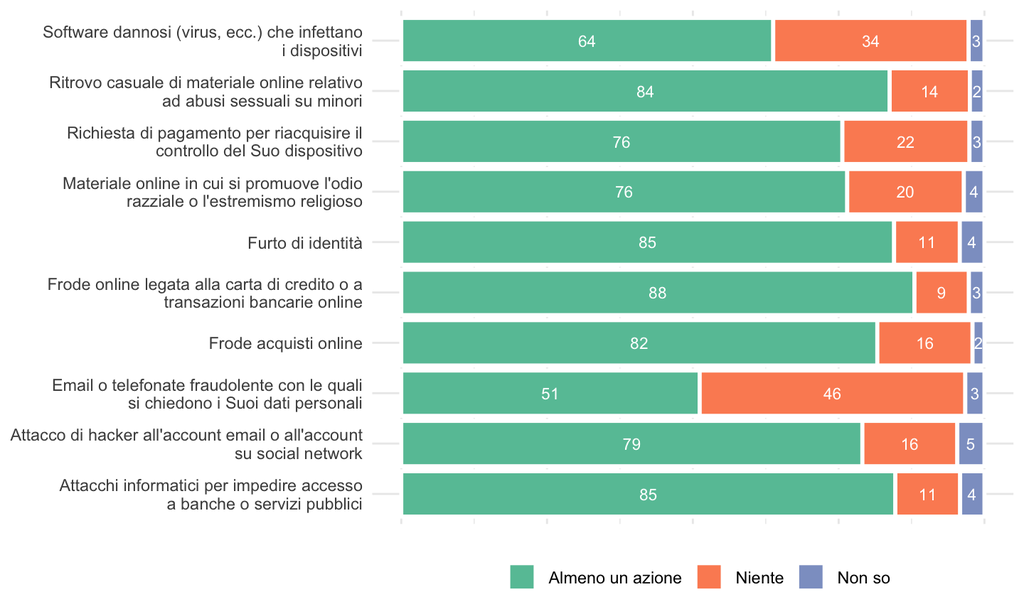

La segnalazione dell’abuso al sito web o al fornitore del servizio Internet (ISP) è l’azione intrapresa dalla maggior parte degli intervistati vittime dei crimini.

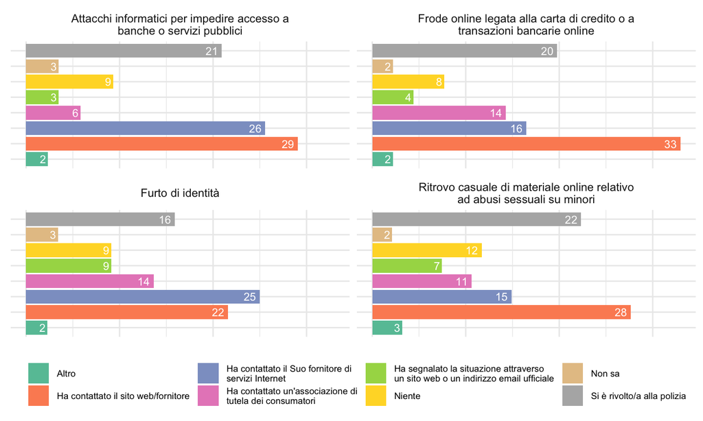

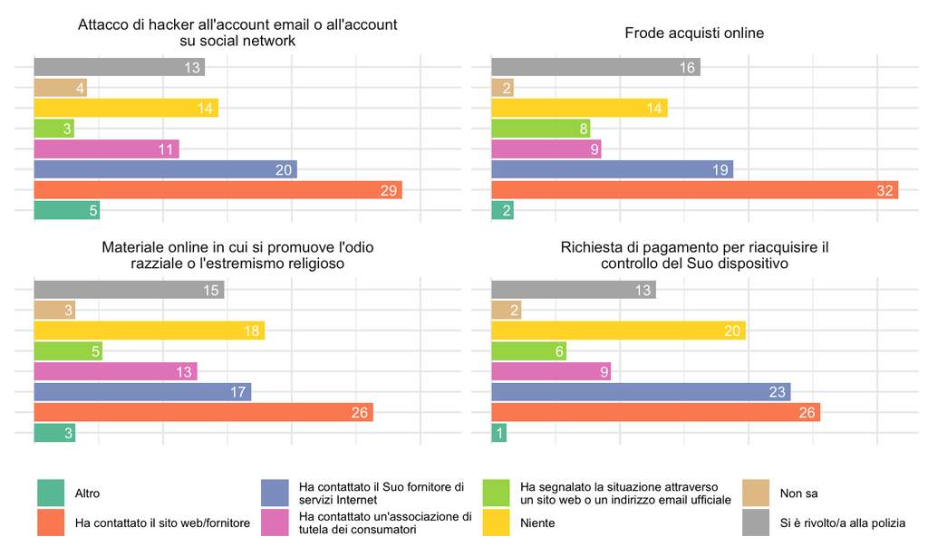

Mentre quando si tratta di software dannosi (virus, ecc.) che infettano i dispositivi o email o telefonate fraudolente con le quali si chiedono i dati personali, la maggior parte degli intervistati preferisce non far nulla.

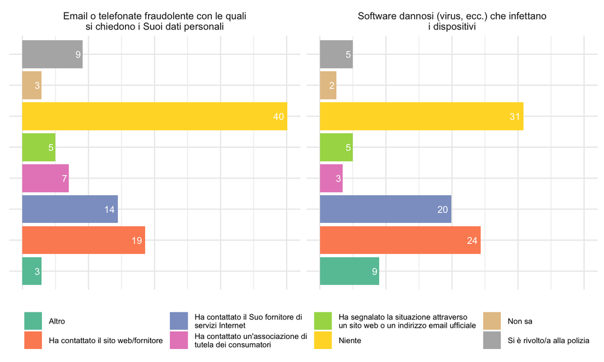

## Segnalazione crimini informatici

La maggioranza degli intervistati (75%) non ha **mai** segnalato un crimine informatico, episodi di bullismo o molestie online, solo il 22% lo ha fatto: il 7% ha segnalato il crimine alla Polizia, circa il 6% alle associazioni di tutela dei consumatori, il 5% al sito web ufficiale e il 4% al fornitore di servizi Internet (ISP).

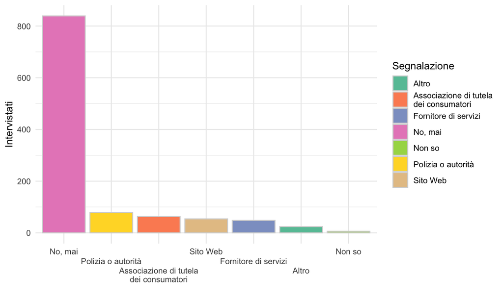